# Arthritis Clinical Trial

Peiyu Li

2022-11-26

# Nov21-25

## 1)Data Description

Data are from a clinical trial comparing auranofin therapy (3 mg of oral gold, twice daily) and placebo for the treatment of rheumatoid arthritis (Bombardier et al., 1986). In this six-month, randomized, double-blind trial, 303 patients with classic or definite rheumatoid arthritis were randomized to one of the two treatment groups and followed over time.

The outcome variable is a global impression scale (*Arthritis Categorical Scale*) measured at baseline (month 0), month 2, month 4, and month 6. This is a self-assessment of a patient’s current arthritis, measured on a 5-level ordinal scale: (1) very good, (2) good, (3) fair, (4) poor, and (5) very poor. Baseline data on this outcome variable are available for 303 of the patients who participated in this trial; follow-up data at 6 months are available for 294 patients.

Variable List: ID, Treatment (0=placebo, 1=auranofin therapy), baseline age (years), Arthritis Categorical Scale month 0, Arthritis Categorical Scale month 2, Arthritis Categorical Scale month 4, Arthritis Categorical Scale month 6.

### Objective

Goal: assess changes in the odds of a more favorable response over the duration of the study, and determine whether treatment with auranofin has an influence on these changes.

Letting $Y_{ij}$ denote the ordinal response for the $i^{th}$ subject at the $j^{th}$ occasion, we assume that the log odds of a more favorable response at each occasion follows the proportional odds model
$$log\{\frac{Pr(Y_{ij} \leq k)}{Pr(Y_{ij}>k)}\}=\alpha_k + \beta_1Trt_i
+ \beta_2\sqrt{Month_{ij}} + \beta_3Trt_i \times \sqrt{Month_{ij}}$$

```r
#Load data:
#library(foreign)
arthritis <- read.dta("arthritis.dta")

#arthritis <- arthritis %>% drop_na()

#transform data into long format
arthritis_long <- arthritis %>% pivot_longer(
  cols=starts_with("y"),
  names_to = "time",
  names_prefix = "y",
  values_to = "y",
  values_drop_na = FALSE) #drop missing values?

#attach(arthritis_long)
arthritis_long$time <- as.numeric(arthritis_long$time)
arthritis_long$y <- as.factor(arthritis_long$y)
arthritis_long$month <- 2*(arthritis_long$time-1)
arthritis_long$sqrtmonth <- arthritis_long$month^0.5
```

## 2)Dichotomous response variable

### ordgee & geeglm

- If the Arthritis Categorical Scale is (1) very good or (2) good, the new response variable y1 = 1.
- If the Arthritis Categorical Scale is (3) fair or (4) poor or (5) very poor, the new response variable y1 = 0.

```r
arthritis_long <- arthritis_long %>%
  mutate(y1 = case_when(y==1 | y==2 ~ 1, #very good | good
                        y==3 | y==4 | y==5 ~ 0)) #fair | poor | very poor

#arthritis_long$y1 <- as.factor(arthritis_long$y1)
model1 <- ordgee(ordered(y1) ~ trt + sqrtmonth + trt:sqrtmonth,
                data = arthritis_long, id = id,
                waves = time, mean.link = "logit",
                corstr = "unstructured")
#summary(model1)

#SAME AS:
gee.in <- geeglm(y1 ~ trt + sqrtmonth + trt:sqrtmonth, data = arthritis_long,
              family = "binomial", id=id, waves = time,
              corstr = "ar1", scale.fix = TRUE)
#summary(gee.in)
#QIC(gee.in)
```

# Nov 28-Dec 2

# Dec 5-9

1. Extract details from glm() models for table construction using screenreg() from *texreg* package.

```r
# library(texreg)
extract.glm <- function(model, include.aic = FALSE, include.bic = FALSE,
                        include.loglik = FALSE, include.deviance = FALSE,
                        include.nobs = TRUE, ...) {
  s <- summary(model, ...)

  coefficient.names <- rownames(s$coef)
  coefficients <- s$coef[, 1]
  standard.errors <- s$coef[, 2]
  significance <- s$coef[, 4]

  aic <- AIC(model)
  bic <- BIC(model)
  lik <- logLik(model)[1]
  dev <- deviance(model)
  n <- nobs(model)

  gof <- numeric()
  gof.names <- character()
  gof.decimal <- logical()
  if (include.aic == TRUE) {
    gof <- c(gof, aic)
    gof.names <- c(gof.names, "AIC")
    gof.decimal <- c(gof.decimal, TRUE)
  }
  if (include.bic == TRUE) {
    gof <- c(gof, bic)
    gof.names <- c(gof.names, "BIC")
    gof.decimal <- c(gof.decimal, TRUE)
  }
  if (include.loglik == TRUE) {
    gof <- c(gof, lik)
    gof.names <- c(gof.names, "Log Likelihood")
    gof.decimal <- c(gof.decimal, TRUE)
  }
  if (include.deviance == TRUE) {
    gof <- c(gof, dev)
    gof.names <- c(gof.names, "Deviance")
    gof.decimal <- c(gof.decimal, TRUE)
  }
  if (include.nobs == TRUE) {
    gof <- c(gof, n)
    gof.names <- c(gof.names, "Num. obs.")
    gof.decimal <- c(gof.decimal, FALSE)
  }

  tr <- createTexreg(
    coef.names = coefficient.names,
    coef = coefficients,
    se = standard.errors,
    pvalues = significance,
    gof.names = gof.names,
    gof = gof,
    gof.decimal = gof.decimal
  )
  return(tr)
}
# Finally, the new function needs to be registered as a method for the generic extract function. This is done using a simple command:
setMethod("extract", signature = className("glm", "stats"),
          definition = extract.glm)
```

2. Extract details from geeglm() models for table construction using screenreg() from *texreg* package.
- did not include correlation (since different correlation structures have different number of correlation estimates)
- added QIC statistics

```r
extract.geeglm <- function(model,
                           include.scale = TRUE,
                           include.correlation = FALSE,
                           include.nobs = TRUE,
                           include.qic = TRUE,
                           include.qicu=TRUE,
                           ...) {
  s <- summary(model)
  names <- rownames(s$coef)
  co <- s$coef[, 1]
  se <- s$coef[, 2]
  pval <- s$coef[, 4]

  gof <- numeric()
  gof.names <- character()
  gof.decimal <- logical()

  if (include.scale == TRUE) {
    gof = c(gof, s$geese$scale$estimate, s$geese$scale$san.se)
    gof.names = c(gof.names, "Scale parameter: gamma", "Scale parameter: SE")
    gof.decimal = c(gof.decimal, TRUE, TRUE)
  }
  if (include.correlation == TRUE) {
    gof = c(gof, s$geese$correlation$estimate, s$geese$correlation$san.se)
    gof.names = c(gof.names, "Correlation parameter: alpha",
                  "Correlation parameter: SE")
    gof.decimal = c(gof.decimal, TRUE, TRUE)
  }
  if (include.nobs == TRUE) {
    n <- nrow(model.frame(model))
    nclust <- length(s$geese$clusz)
    gof = c(gof, n, nclust)
    gof.names = c(gof.names, "Num. obs.", "Num. clust.")
    gof.decimal = c(gof.decimal, FALSE, FALSE)
  }
  if (include.qic == TRUE){       #add QIC into extract.geeglm
    gof = c(gof, QIC(model)[1])
    gof.names = c(gof.names, "QIC")
    gof.decimal = c(gof.decimal, TRUE)
  }
  if (include.qicu == TRUE){       #add QICu into extract.geeglm
    gof = c(gof, QIC(model)[2])
    gof.names = c(gof.names, "QICu")
    gof.decimal = c(gof.decimal, TRUE)
  }
  tr <- createTexreg(
    coef.names = names,
    coef = co,
    se = se,
    pvalues = pval,
    gof.names = gof.names,
    gof = gof,
    gof.decimal = gof.decimal
  )
  return(tr)
}
# Finally, the new function needs to be registered as a method for the generic extract function. This is done using a simple command:
setMethod("extract", signature = className("geeglm", "geepack"),
          definition = extract.geeglm)
```

## 1) n = 303

```r
mod1 <- glm(y1 ~ trt + sqrtmonth + trt:sqrtmonth, data = arthritis_long,
              family = "binomial")
mod2 <- geeglm(y1 ~ trt + sqrtmonth + trt:sqrtmonth, data = arthritis_long,
              family = "binomial", id=id, waves = time,
              corstr = "independence", scale.fix = TRUE)
mod3 <- geeglm(y1 ~ trt + sqrtmonth + trt:sqrtmonth, data = arthritis_long,
              family = "binomial", id=id, waves = time,
              corstr = "exchangeable", scale.fix = TRUE)
mod4 <- geeglm(y1 ~ trt + sqrtmonth + trt:sqrtmonth, data = arthritis_long,
              family = "binomial", id=id, waves = time,
              corstr = "ar1", scale.fix = TRUE)
mod5 <- geeglm(y1 ~ trt + sqrtmonth + trt:sqrtmonth, data = arthritis_long,
              family = "binomial", id=id, #waves = time,
              corstr = "unstructured", scale.fix = TRUE)
#summary(mod3)

# screenreg(list(mod1,mod2,mod3,mod4,mod5),single.row = FALSE,
#           custom.header = list("GLM"=1,"GEE"=2:5),
#           custom.model.names = c("Logistic","Independence","Exchangeable",
#                                  "AR(1)","Unstructured"),
#           caption="Table1", caption.above=TRUE)
```

```r
Table1<-htmlreg(list(mod1,mod2,mod3,mod4,mod5),single.row = FALSE,
          custom.header = list("GLM"=1,"GEE"=2:5),
          custom.model.names = c(" ","Independence","Exchangeable",
                                 "AR(1)","Unstructured"),
          caption="Table 1: Comparison of GLM and GEE Models with Different Correlation Structures(N=303 individuals)", caption.above=TRUE)
htmltools::HTML(Table1)
```

Table 1: Comparison of GLM and GEE Models with Different Correlation Structures(N=303 individuals)

|  | GLM | GEE Independence | GEE Exchangeable | GEE AR(1) | GEE Unstructured |
| --- | --- | --- | --- | --- | --- |
| (Intercept) | -1.19*** | -1.19*** | -1.19*** | -1.28*** | -1.22*** |
|  | (0.18) | (0.18) | (0.18) | (0.20) | (0.18) |
| trt | -0.07 | -0.07 | -0.07 | 0.02 | -0.04 |
|  | (0.25) | (0.26) | (0.26) | (0.28) | (0.26) |
| sqrtmonth | 0.29** | 0.29*** | 0.28*** | 0.35*** | 0.29*** |
|  | (0.10) | (0.08) | (0.08) | (0.09) | (0.08) |
| trt:sqrtmonth | 0.22 | 0.22 | 0.22 | 0.16 | 0.22 |
|  | (0.14) | (0.12) | (0.12) | (0.12) | (0.12) |
| Num. obs. | 1194 | 1194 | 1194 | 1194 | 1194 |
| Scale parameter: gamma |  | 1.00 | 1.00 | 1.00 | 1.00 |
| Scale parameter: SE |  | 0.00 | 0.00 | 0.00 | 0.00 |
| Num. clust. |  | 303 | 303 | 303 | 303 |
| QIC |  | 1515.65 | 1515.68 | 1516.76 | 1515.82 |
| QICu |  | 1512.09 | 1512.13 | 1512.50 | 1512.25 |

***p < 0.001; **p < 0.01; *p < 0.05

## 2) n = 50

- Randomly select 50 individuals from the original dataset.

```r
set.seed(2)
list_50 <- sample(1:nrow(arthritis), 50, replace = FALSE)
arthritis_50 <- arthritis_long[arthritis_long$id %in% list_50,]

mod1_50 <- glm(y1 ~ trt + sqrtmonth + trt:sqrtmonth, data = arthritis_50,
              family = "binomial")
mod2_50 <- geeglm(y1 ~ trt + sqrtmonth + trt:sqrtmonth, data = arthritis_50,
              family = "binomial", id=id, waves = time,
              corstr = "independence", scale.fix = TRUE)
mod3_50 <- geeglm(y1 ~ trt + sqrtmonth + trt:sqrtmonth, data = arthritis_50,
              family = "binomial", id=id, waves = time,
              corstr = "exchangeable", scale.fix = TRUE)
mod4_50 <- geeglm(y1 ~ trt + sqrtmonth + trt:sqrtmonth, data = arthritis_50,
              family = "binomial", id=id, waves = time,
              corstr = "ar1", scale.fix = TRUE)
mod5_50 <- geeglm(y1 ~ trt + sqrtmonth + trt:sqrtmonth, data = arthritis_50,
              family = "binomial", id=id, waves = time,
              corstr = "unstructured", scale.fix = TRUE)

Table2<-htmlreg(list(mod1_50,mod2_50,mod3_50,mod4_50,mod5_50),single.row = FALSE,
          custom.header = list("GLM"=1,"GEE"=2:5),
          custom.model.names = c(" ","Independence","Exchangeable",
                                 "AR(1)","Unstructured"),
          caption="Table 2: Comparison of GLM and GEE Models with Different Correlation Structures(N=50 individuals)", caption.above=TRUE)
htmltools::HTML(Table2)
```

Table 2: Comparison of GLM and GEE Models with Different Correlation Structures(N=50 individuals)

|  | GLM | GEE Independence | GEE Exchangeable | GEE AR(1) | GEE Unstructured |
| --- | --- | --- | --- | --- | --- |
| (Intercept) | -1.45** | -1.45** | -1.45** | -1.55** | -1.56** |
|  | (0.45) | (0.47) | (0.47) | (0.49) | (0.50) |
| trt | -0.17 | -0.17 | -0.17 | 0.01 | 0.00 |
|  | (0.68) | (0.74) | (0.74) | (0.73) | (0.73) |
| sqrtmonth | 0.17 | 0.17 | 0.17 | 0.24 | 0.22 |
|  | (0.25) | (0.24) | (0.24) | (0.25) | (0.25) |
| trt:sqrtmonth | 0.59 | 0.59 | 0.58 | 0.47 | 0.51 |
|  | (0.38) | (0.37) | (0.37) | (0.37) | (0.37) |
| Num. obs. | 199 | 199 | 199 | 199 | 199 |
| Scale parameter: gamma |  | 1.00 | 1.00 | 1.00 | 1.00 |
| Scale parameter: SE |  | 0.00 | 0.00 | 0.00 | 0.00 |
| Num. clust. |  | 50 | 50 | 50 | 50 |
| QIC |  | 240.21 | 240.25 | 240.30 | 240.28 |
| QICu |  | 236.81 | 236.82 | 236.93 | 236.88 |

***p < 0.001; **p < 0.01; *p < 0.05

## 3) n = 20

- Randomly select 20 individuals from the original dataset.

```r
set.seed(2)
list_20 <- sample(1:nrow(arthritis), 20, replace = FALSE)
arthritis_20 <- arthritis_long[arthritis_long$id %in% list_20,]

mod1_20 <- glm(y1 ~ trt + sqrtmonth + trt:sqrtmonth, data = arthritis_20,
              family = "binomial")
mod2_20 <- geeglm(y1 ~ trt + sqrtmonth + trt:sqrtmonth, data = arthritis_20,
              family = "binomial", id=id, waves = time,
              corstr = "independence", scale.fix = TRUE)
mod3_20 <- geeglm(y1 ~ trt + sqrtmonth + trt:sqrtmonth, data = arthritis_20,
              family = "binomial", id=id, waves = time,
              corstr = "exchangeable", scale.fix = TRUE)
mod4_20 <- geeglm(y1 ~ trt + sqrtmonth + trt:sqrtmonth, data = arthritis_20,
              family = "binomial", id=id, waves = time,
              corstr = "ar1", scale.fix = TRUE)
mod5_20 <- geeglm(y1 ~ trt + sqrtmonth + trt:sqrtmonth, data = arthritis_20,
              family = "binomial", id=id, waves = time,
              corstr = "unstructured", scale.fix = TRUE)
summary(mod5_20)
```

```
##
## Call:
## geeglm(formula = y1 ~ trt + sqrtmonth + trt:sqrtmonth, family = "binomial",
##     data = arthritis_20, id = id, waves = time, corstr = "unstructured",
##     scale.fix = TRUE)
##
##  Coefficients:
##               Estimate Std.err  Wald Pr(>|W|)
## (Intercept)    -1.7315  0.7962 4.730   0.0296 *
## trt            -0.5838  1.4377 0.165   0.6847
## sqrtmonth       0.4467  0.2829 2.493   0.1143
## trt:sqrtmonth   0.4691  0.5478 0.733   0.3918
## ---
## Signif. codes:  0 '***' 0.001 '**' 0.01 '*' 0.05 '.' 0.1 ' ' 1
##
## Correlation structure = unstructured
## Scale is fixed.
##
##   Link = identity
##
## Estimated Correlation Parameters:
##           Estimate Std.err
## alpha.1:2   0.4979  0.2174
## alpha.1:3   0.5926  0.1649
## alpha.1:4   0.5761  0.1369
## alpha.2:3   0.5565  0.1978
## alpha.2:4   0.3014  0.2030
## alpha.3:4   0.3753  0.2349
## Number of clusters:   20  Maximum cluster size: 4
```

```r
Table3<-htmlreg(list(mod1_20,mod2_20,mod3_20,mod4_20,mod5_20),single.row = FALSE,
          custom.header = list("GLM"=1,"GEE"=2:5),
          custom.model.names = c(" ","Independence","Exchangeable",
                                 "AR(1)","Unstructured"),
          caption="Table 3: Comparison of GLM and GEE Models with Different Correlation Structures(N=20 individuals)", caption.above=TRUE)
htmltools::HTML(Table3)
```

Table 3: Comparison of GLM and GEE Models with Different Correlation Structures(N=20 individuals)

|  | GLM | GEE Independence | GEE Exchangeable | GEE AR(1) | GEE Unstructured |
| --- | --- | --- | --- | --- | --- |
| (Intercept) | -1.68* | -1.68* | -1.69* | -1.47 | -1.73* |
|  | (0.75) | (0.78) | (0.79) | (0.78) | (0.80) |
| trt | -0.58 | -0.58 | -0.55 | -0.63 | -0.58 |
|  | (1.24) | (1.38) | (1.38) | (1.31) | (1.44) |
| sqrtmonth | 0.45 | 0.45 | 0.45 | 0.33 | 0.45 |
|  | (0.41) | (0.27) | (0.27) | (0.26) | (0.28) |
| trt:sqrtmonth | 0.48 | 0.48 | 0.44 | 0.47 | 0.47 |
|  | (0.66) | (0.51) | (0.52) | (0.49) | (0.55) |
| Num. obs. | 79 | 79 | 79 | 79 | 79 |
| Scale parameter: gamma |  | 1.01 | 1.01 | 1.01 | 1.01 |
| Scale parameter: SE |  | 0.00 | 0.00 | 0.00 | 0.00 |
| Num. clust. |  | 20 | 20 | 20 | 20 |
| QIC |  | 101.18 | 101.22 | 101.19 | 101.62 |
| QICu |  | 97.78 | 97.80 | 97.96 | 97.84 |

***p < 0.001; **p < 0.01; *p < 0.05

## 4) geepack:geeglm vs gee::gee

```r
geepack1<- geeglm(y1 ~ trt + sqrtmonth + trt:sqrtmonth, data = arthritis_50,
              family = "binomial", id=id, waves = time,
              corstr = "unstructured", scale.fix = TRUE)

summary(geepack1)
```

```
##
## Call:
## geeglm(formula = y1 ~ trt + sqrtmonth + trt:sqrtmonth, family = "binomial",
##     data = arthritis_50, id = id, waves = time, corstr = "unstructured",
##     scale.fix = TRUE)
##
##  Coefficients:
##               Estimate  Std.err Wald Pr(>|W|)
## (Intercept)   -1.56072  0.49793 9.82   0.0017 **
## trt            0.00456  0.73288 0.00   0.9950
## sqrtmonth      0.21724  0.25150 0.75   0.3877
## trt:sqrtmonth  0.51007  0.36732 1.93   0.1650
## ---
## Signif. codes:  0 '***' 0.001 '**' 0.01 '*' 0.05 '.' 0.1 ' ' 1
##
## Correlation structure = unstructured
## Scale is fixed.
##
##   Link = identity
##
## Estimated Correlation Parameters:
##           Estimate Std.err
## alpha.1:2    0.387   0.155
## alpha.1:3    0.135   0.152
## alpha.1:4    0.148   0.148
## alpha.2:3    0.367   0.147
## alpha.2:4    0.364   0.154
## alpha.3:4    0.414   0.141
## Number of clusters:   50  Maximum cluster size: 4
```

```r
#library(gee)
gee1 <- gee(y1 ~ trt + sqrtmonth + trt:sqrtmonth, data = arthritis_50,
              family = "binomial", id=id,
              corstr = "unstructured", scale.fix = TRUE)
```

```
## Beginning Cgee S-function, @(#) geeformula.q 4.13 98/01/27
```

```
## running glm to get initial regression estimate
```

```
##   (Intercept)           trt     sqrtmonth trt:sqrtmonth
##        -1.452        -0.168         0.170         0.593
```

```r
summary(gee1)
```

```
##
##  GEE:  GENERALIZED LINEAR MODELS FOR DEPENDENT DATA
##  gee S-function, version 4.13 modified 98/01/27 (1998)
##
## Model:
##  Link:                      Logit
##  Variance to Mean Relation: Binomial
##  Correlation Structure:     Unstructured
##
## Call:
## gee(formula = y1 ~ trt + sqrtmonth + trt:sqrtmonth, id = id,
##     data = arthritis_50, family = "binomial", corstr = "unstructured",
##     scale.fix = TRUE)
##
## Summary of Residuals:
##    Min     1Q Median     3Q    Max
## -0.556 -0.263 -0.174  0.444  0.826
##
##
## Coefficients:
##               Estimate Naive S.E.  Naive z Robust S.E. Robust z
## (Intercept)   -1.55813      0.487 -3.20250       0.497 -3.13512
## trt            0.00142      0.727  0.00195       0.733  0.00194
## sqrtmonth      0.21608      0.246  0.87779       0.251  0.86071
## trt:sqrtmonth  0.51164      0.364  1.40621       0.367  1.39325
##
## Estimated Scale Parameter:  1
## Number of Iterations:  5
##
## Working Correlation
##       [,1]  [,2]  [,3]  [,4]
## [1,] 1.000 0.385 0.134 0.144
## [2,] 0.385 1.000 0.364 0.354
## [3,] 0.134 0.364 1.000 0.403
## [4,] 0.144 0.354 0.403 1.000
```

## Matching

Packages: optmatch, cobalt

### a) optimal pair matching

- no restrictions are placed upon the maximum acceptable difference between the propensity scores of two matched subjects.

```r
#library(optmatch)

# subject 211 has missing age value
arthritis <- arthritis %>% filter(!is.na(age))

#check the number of treated and control subjects
table(arthritis$trt)
```

```
##
##   0   1
## 149 153
```

```r
ps <- glm(trt ~ age, family = binomial, data=arthritis)

#match directly on the propensity score without restricting the sample to the region of overlap
ps.pm <- pairmatch(ps, data=arthritis)
summary(ps.pm)
```

```
## Structure of matched sets:
## 1:0 1:1
##   4 149
## Effective Sample Size:  149
## (equivalent number of matched pairs).
```

```r
# print(ps.pm, grouped=TRUE)
#join the match factor back to the original data.frame
arthritis.matched <- data.frame(arthritis, matches = ps.pm, check.rows=TRUE)

arthritis.matched <- arthritis.matched %>% filter(!is.na(matches))
```

### b) caliper distance

- Matching within a specified *caliper distance*
- further restriction that the absolute difference in the propensity scores of matched subjects must be below some prespecified threshold (the caliper distance).
- we want to imply a caliper to the distances generated by the propensity score model
- To do this requires a more explicit generation of the match, involving separate steps for generation of the distances followed by matching upon those distances.

```r
# First, we create a distance matrix based upon ps:
ps.dist <- match_on(ps, data = arthritis)
#summary(ps.dist)
```

ps.dist is a matrix with an entry corresponding to the distance between each potential pair of treatment and control units. We can caliper directly on this distance matrix:

```r
#caliper(ps.dist,2)

ps.pm2 <- pairmatch(ps.dist + caliper(ps.dist, 2), data = arthritis)
#all.equal(ps.pm, ps.pm2, check.attributes=FALSE)
summary(ps.pm2)
```

```
## Structure of matched sets:
## 1:0 1:1
##   4 149
## Effective Sample Size:  149
## (equivalent number of matched pairs).
```

Entries which are Inf will never be matched. Adding the caliper to ps.dist will disallow matching between units which differ by more than 2 standard deviations.

### c) checking balance

```r
library(cobalt)

covs0 <- subset(arthritis, select = c(age))
p.score <- ps$fitted.values #get the propensity score

bal.tab(ps.pm, covs = covs0, distance = ~p.score)
```

```
## Balance Measures
##             Type Diff.Adj
## p.score Distance    0.037
## age      Contin.   -0.037
##
## Sample sizes
##           Control Treated
## All           149     153
## Matched       149     149
## Unmatched       0       4
```

# Dec13

### Summary of comparison tables

N=303:  
* GLM and GEE model with independent correlation structure have the same parameter estimates, the estimated standard errors are a bit different since GEE uses robust sandwich estimator.  
* Exchangeable GEE also have similar parameter estimates with independent.GEE is asymptotically equivalent and provides consistent estimates even though we have different working correlation structures. Standard errors are similar.  
* AR(1) is a little bit different, but it has the largest QIC. We expect AR(1) to be more similar, but maybe the sample size is still not big enough to show the asymptotic equivalence.  
* Standard errors are similar between all the models.

N=50:  
* Similar between independent & exchangeable, but more difference in AR(1) and unstructured.

N=20:  
* For interaction, we see Greater difference in standard error estimates between independent and logistic regression(GLM).  
* Greater difference among all the standard error estimates between different working correlation structures.

Overall:  
* Standard error estimates are greater when the sample size is smaller because standard error is a function of sample size.  
* QIC is the largest when sample size is the largest. Independent correlation structure has the lowest QIC across different sample size situations.  
* During the *simulation*, we’ll vary the strength of correlation between outcomes to see if the true correlation structure AR(1). If the correlation is very strong, then we should see assuming the AR(1) will have the lowest QIC.

### QIC vs QICu

The QIC is used to compare the relative goodness-of-fit of different GEE models by calculating a penalized likelihood function. The QICu variant is an extension of the QIC that takes into account the *number of parameters* being estimated by each model, which can help to balance the comparison and provide more accurate results.

For example, AR(1) estimates a parameter that the other model (independence) does not, using QICu may provide a more balanced comparison than using QIC alone. This is because QICu takes into account the difference in the number of parameters being estimated by each model, whereas QIC does not. Therefore, it is possible that QICu may provide a better comparison in this situation than QIC.

QICu approximates QIC when the GEE model is correctly specified. QICu, defined as Q+2p, adds a penalty (2p) to the quasilikelihood (Q), where p is the number of parameters in the model. Models do not need to be nested in order to use QIC or QICu to compare them. Note that QICu should not be used for selecting a working correlation structure.

### Plot

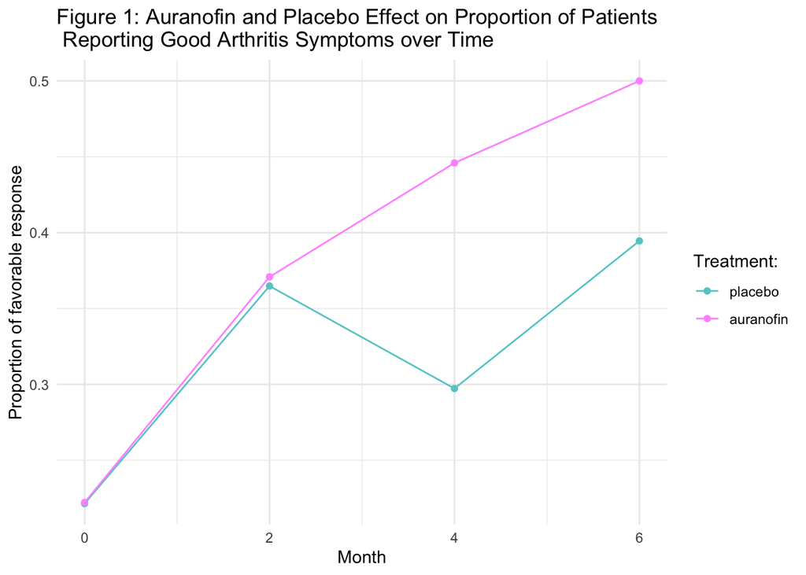

```r
library(ggplot2)
summary_data <- arthritis_long %>% drop_na() %>%
  group_by(month, trt) %>%
  summarise(proportion = sum(y1) / n())
summary_data$trt <- as.factor(summary_data$trt)

ggplot(summary_data, aes(x = month, y = proportion, color = trt)) +
  geom_point()+
  geom_line()+
  labs(x="Month",y="Proportion of favorable response",
       title="Figure 1: Auranofin and Placebo Effect on Proportion of Patients \n Reporting Good Arthritis Symptoms over Time",
       color="Treatment:")+
  scale_color_manual(labels = c("placebo","auranofin"),
                     values = c("#66CCCC","#FF99FF"))+
  theme_minimal()
```